# R Notebook

The goal here is to use conventional alpha diversity metrics to see how Chao1 richness, shannon diversity and evenness change across samples and to compare those to the values seen using breakaway in the AlphaDiversity.Rmd file

# Setup

Run AlphaDiversity in scratchnotebooks That file calculates richness in breakawy which I will combine here

```r
#source(here::here("RScripts", "InitialProcessing_3.R"))
source(here::here("RLibraries", "ChesapeakePersonalLibrary.R"))
ksource(here::here("ActiveNotebooks", "BreakawayAlphaDiversity.Rmd"))
```

```
processing file: /home/jacob/Projects/ChesapeakeMainstemAnalysis_3/ActiveNotebooks/BreakawayAlphaDiversity.Rmd
```

[output not shown]

```
output file: /tmp/Rtmp5FxWFO/file2ff44d8eccb

Warning: Assuming taxa are rows
```

```r
library(vegan)
library(cowplot)
library(flextable)
library(ftExtra)
```

This file is dedicated to conventional, non div-net/breakaway stats, since breakaway seems to choke on this data.

Reshape back into an ASV matrix, but this time correcting for total abundance

```r
raDf <- nonSpikes_Remake %>% pivot_wider(id_cols = ID, names_from = ASV, values_from = RA, values_fill = 0)
raMat <- raDf %>% column_to_rownames("ID")
```

```r
raMat1 <- raMat %>% as.matrix()
```

```r
countMat <-  nonSpikes_Remake %>%
  pivot_wider(id_cols = ID, names_from = ASV, values_from = reads, values_fill = 0) %>%
  column_to_rownames("ID") %>% as.matrix()
```

```r
seqDep <- countMat %>% apply(1, sum)
names(seqDep) <- rownames(countMat)
min(seqDep)
```

```
[1] 852
```

This value is lower than the lowist chimera checked value because the spikes have been discarded (while chimera checked read depth still has spikes)

```r
sampleRichness <- rarefy(countMat, min(seqDep))
```

rarefy everything to the minimum depth (852)

```r
countRare <- rrarefy(countMat, min(seqDep))
```

Gamma diversity

```r
specpool(countRare)
```

|  | Species | chao | chao.se | jack1 | jack1.se | jack2 | boot | boot.se | n |
| --- | --- | --- | --- | --- | --- | --- | --- | --- | --- |
| All | 7167 | 36126.09 | 1532.816 | 12480.2 | 783.5185 | 17247.27 | 9217.246 | 326.0107 | 75 |

Doesn’t finish

```r
#specpool(countMat)
```

# Calculate diversity indeces

All richness estimates

```r
richnessRare <- estimateR(countRare)
```

Shannon diversity

```r
shan <- diversity(countRare)
shan
```

```
 3-1-B-0-2  3-1-B-1-2  3-1-B-180   3-1-B-20    3-1-B-5  3-1-B-500   3-1-B-53  3-1-S-0-2  3-1-S-1-2  3-1-S-180   3-1-S-20
  4.422220   5.177712   4.673965   5.856138   5.306028   3.867173   5.524740   4.556509   4.908324   4.723596   5.258465
   3-1-S-5  3-2-B-0-2  3-2-B-1-2  3-2-B-180   3-2-B-20    3-2-B-5  3-2-B-500   3-2-B-53  3-2-S-0-2  3-2-S-1-2  3-2-S-180
  4.784024   4.360941   4.718890   4.550748   5.072977   5.519108   5.046567   4.920680   3.731992   4.952246   4.767468
  3-2-S-20    3-2-S-5  3-2-S-500   3-2-S-53  3-3-B-0-2  3-3-B-1-2  3-3-B-180   3-3-B-20    3-3-B-5  3-3-B-500   3-3-B-53
  4.863097   5.223329   4.897641   4.290082   4.248899   4.957467   3.445815   5.756081   5.286143   5.271160   5.391336
 3-3-S-180   3-3-S-20  3-3-S-500   3-3-S-53  4-3-B-0-2  4-3-B-1-2  4-3-B-180   4-3-B-20    4-3-B-5  4-3-B-500   4-3-B-53
  4.973717   4.941152   4.934242   4.299805   4.305491   4.870454   4.449119   4.382465   4.675261   4.378602   4.218013
 4-3-O-1-2  4-3-O-180    4-3-O-5  4-3-O-500   4-3-O-53  4-3-S-0-2  4-3-S-180   4-3-S-20  4-3-S-500   4-3-S-53  5-1-S-1-2
  5.005949   4.669355   5.149317   4.051148   4.526204   2.805419   4.582933   4.584583   4.746818   4.507648   4.441563
 5-1-S-180   5-1-S-20    5-1-S-5  5-1-S-500   5-1-S-53  5-5-B-0-2  5-5-B-180    5-5-B-5  5-5-B-500   5-5-B-53  5-5-S-180
  4.578301   3.987230   3.912126   3.924126   4.046272   4.703641   5.180034   5.491216   5.022332   4.964536   4.237432
   5-5-S-5  5-5-S-500   5-5-S-53 C_5P1B_0P2 C_5P1B_180 C_5P1B_1P2  C_5P1B_20 C_5P1B_500  C_5P1B_53
  5.051088   4.971152   4.132580   4.283304   4.779422   4.775492   5.387275   4.650271   5.120887
```

Evenness

```r
pielouJ <- shan/richnessRare["S.chao1",]
pielouJ
```

```
  3-1-B-0-2   3-1-B-1-2   3-1-B-180    3-1-B-20     3-1-B-5   3-1-B-500    3-1-B-53   3-1-S-0-2   3-1-S-1-2   3-1-S-180
0.013491634 0.009318950 0.010175013 0.003432068 0.006674249 0.040994764 0.009053606 0.010571265 0.008319745 0.008291860
   3-1-S-20     3-1-S-5   3-2-B-0-2   3-2-B-1-2   3-2-B-180    3-2-B-20     3-2-B-5   3-2-B-500    3-2-B-53   3-2-S-0-2
0.007686691 0.007027230 0.012104637 0.008069496 0.012639902 0.005446721 0.005766554 0.009571859 0.009788340 0.021084699
  3-2-S-1-2   3-2-S-180    3-2-S-20     3-2-S-5   3-2-S-500    3-2-S-53   3-3-B-0-2   3-3-B-1-2   3-3-B-180    3-3-B-20
0.008840666 0.008940059 0.009968447 0.008712937 0.007712544 0.014412369 0.014943372 0.008377093 0.069262609 0.005289256
    3-3-B-5   3-3-B-500    3-3-B-53   3-3-S-180    3-3-S-20   3-3-S-500    3-3-S-53   4-3-B-0-2   4-3-B-1-2   4-3-B-180
0.007432388 0.006345790 0.005173342 0.008648463 0.008655362 0.009731856 0.010460474 0.010851043 0.009461060 0.011477154
   4-3-B-20     4-3-B-5   4-3-B-500    4-3-B-53   4-3-O-1-2   4-3-O-180     4-3-O-5   4-3-O-500    4-3-O-53   4-3-S-0-2
0.010183115 0.008781941 0.007594759 0.009085782 0.008509481 0.009128748 0.006349169 0.016867383 0.010281293 0.124685269
  4-3-S-180    4-3-S-20   4-3-S-500    4-3-S-53   5-1-S-1-2   5-1-S-180    5-1-S-20     5-1-S-5   5-1-S-500    5-1-S-53
0.012995085 0.010612461 0.010562177 0.012295494 0.010725274 0.011071401 0.014227406 0.010664586 0.013185906 0.013578092
  5-5-B-0-2   5-5-B-180     5-5-B-5   5-5-B-500    5-5-B-53   5-5-S-180     5-5-S-5   5-5-S-500    5-5-S-53  C_5P1B_0P2
0.009430089 0.010061479 0.006531518 0.010322357 0.009140119 0.015943514 0.008634339 0.009110633 0.017182413 0.006377415
 C_5P1B_180  C_5P1B_1P2   C_5P1B_20  C_5P1B_500   C_5P1B_53
0.006826557 0.005847064 0.004299668 0.007465518 0.005200600
```

## Combine diversity data

```r
diversityData <- sampleData %>%
  left_join(richnessRare %>% t() %>% as.data.frame() %>% rownames_to_column("ID"), by = "ID") %>%
  left_join(shan %>% enframe(name = "ID", value = "shannonH"), by = "ID") %>%
  left_join(pielouJ %>% enframe(name = "ID", value = "pielouJ"), by = "ID") %>%
  arrange(Size_Class) %>%
  mutate(Depth = ordered(Depth, levels = c("Surface", "Oxycline", "Bottom")))
```

# Generate plots of diversity estimates

Parameters for all plots

```r
plotSpecs <- list(
  facet_wrap(~Depth, ncol = 1) ,
  theme_bw(base_size = 16) ,
  geom_point(size = 4) ,
  geom_path(aes(color = as.factor(Station))) ,
  scale_x_log10(breaks = my_sizes, labels = as.character(my_sizes)) ,
  #scale_y_log10nice() ,
  scale_shape_manual(values = rep(21:25, 2)) ,
  scale_fill_viridis_d(option = "plasma") ,
  scale_color_viridis_d(option = "plasma") ,
  labs(x = expression(paste("Particle Size (", mu, "m)"))) ,
  theme(legend.position = "none",
        plot.margin = unit(c(0, 0, 0, 0), "cm"),
        axis.title.x = element_blank(),
        axis.text.x = element_text(angle = 90, vjust = .5),
        axis.title.y = element_text(margin = unit(c(3, 3, 3, 3), "mm"), vjust = 0))
)
```

Observed species counts, on rarefied data

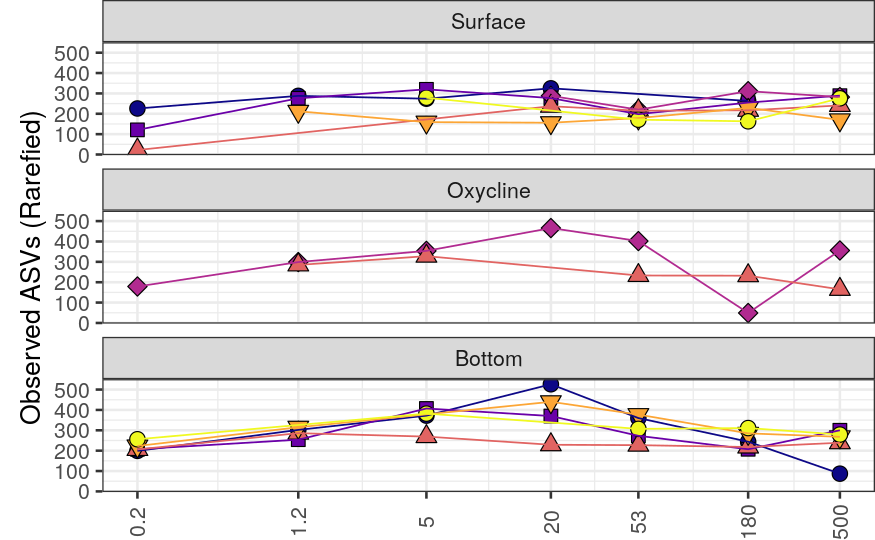

```r
plotObs <- diversityData %>%
#filter(Depth %in% c("Surface", "Bottom")) %>%
  ggplot(aes(x = Size_Class, y = S.obs, shape = as.factor(Station), fill = as.factor(Station))) +
  plotSpecs +ylab("Observed ASVs (Rarefied)")#+ scale_y_log10()
plotObs
```

Estemated Chao1 Richness

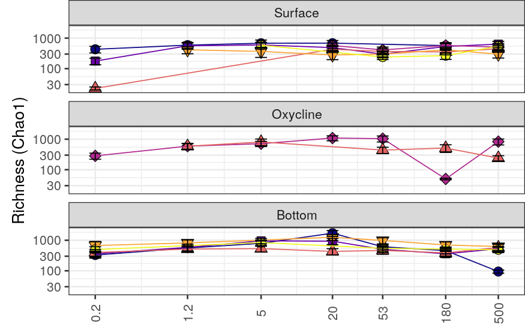

```r
plotChao1 <- diversityData %>%
#filter(Depth %in% c("Surface", "Bottom")) %>%
  ggplot(aes(x = Size_Class, y = S.chao1, shape = as.factor(Station), fill = as.factor(Station))) +
  plotSpecs +
  geom_errorbar(aes(ymin = S.chao1 -2 * se.chao1, ymax = S.chao1 + 2* se.chao1), width = -.1) +
  scale_y_log10() +
  ylab("Richness (Chao1)")
plotChao1
```

Shannon diversity

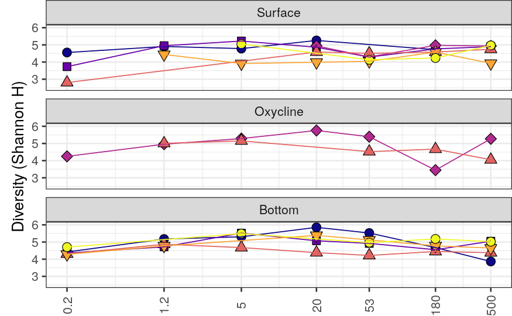

```r
plotShan <- diversityData %>%
#filter(Depth %in% c("Surface", "Bottom")) %>%
  ggplot(aes(x = Size_Class, y = shannonH, shape = as.factor(Station), fill = as.factor(Station))) +
  plotSpecs +
  ylab("Diversity (Shannon H)") +
  lims(y = c(2.5, 6))
plotShan
```

Evenness

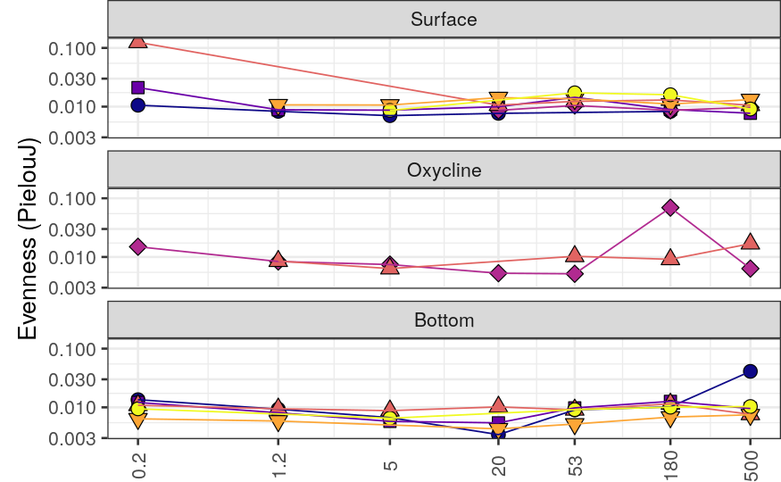

```r
plotPielou <- diversityData %>%

#filter(Depth %in% c("Surface", "Bottom")) %>%
  ggplot(aes(x = Size_Class, y = pielouJ, shape = as.factor(Station), fill = as.factor(Station))) +
  plotSpecs +scale_y_log10() +ylab("Evenness (PielouJ)")
plotPielou
```

All plots together

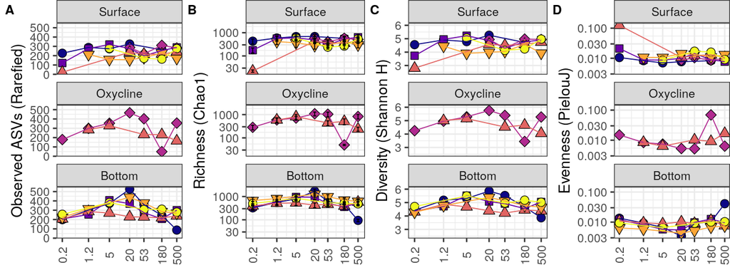

```r
plotAlpha <- plot_grid(plotObs, plotChao1, plotShan, plotPielou, nrow = 1, labels = LETTERS)
plotAlpha
```

```r
ggsave(here::here("Figures", "ConventionalAlpha.png"), plotAlpha, width = 11, height = 4)
```

## Do we see trends with lat and size?

## Observed Species

Rarefied observed species numbers

```r
obsMod <- lm(S.obs ~ log(Size_Class) + I(log(Size_Class)^2) + I(log(Size_Class)^2) + lat + I(lat^2) + depth, data = diversityData)
summary(obsMod)
```

```
Call:
lm(formula = S.obs ~ log(Size_Class) + I(log(Size_Class)^2) +
    I(log(Size_Class)^2) + lat + I(lat^2) + depth, data = diversityData)

Residuals:
     Min       1Q   Median       3Q      Max
-225.110  -32.235    0.055   51.370  188.364

Coefficients:
                       Estimate Std. Error t value Pr(>|t|)
(Intercept)          257457.281 135283.523   1.903 0.061201 .
log(Size_Class)          33.141      8.196   4.043 0.000135 ***
I(log(Size_Class)^2)     -6.436      1.525  -4.221 7.29e-05 ***
lat                  -13407.519   7049.449  -1.902 0.061356 .
I(lat^2)                174.631     91.770   1.903 0.061225 .
depth                     4.120      3.246   1.269 0.208615
---
Signif. codes:  0 ‘***’ 0.001 ‘**’ 0.01 ‘*’ 0.05 ‘.’ 0.1 ‘ ’ 1

Residual standard error: 77.06 on 69 degrees of freedom
Multiple R-squared:  0.2632,    Adjusted R-squared:  0.2098
F-statistic: 4.929 on 5 and 69 DF,  p-value: 0.000647
```

## Richness

Rarified chao1 estimates

```r
chao1Mod <- lm(S.chao1 ~ log(Size_Class) + I(log(Size_Class)^2) + I(log(Size_Class)^2) + lat + I(lat^2) + depth, data = diversityData)
summary(chao1Mod)
```

```
Call:
lm(formula = S.chao1 ~ log(Size_Class) + I(log(Size_Class)^2) +
    I(log(Size_Class)^2) + lat + I(lat^2) + depth, data = diversityData)

Residuals:
    Min      1Q  Median      3Q     Max
-543.97 -142.09  -39.36  135.62  965.02

Coefficients:
                      Estimate Std. Error t value Pr(>|t|)
(Intercept)          864787.87  429356.50   2.014  0.04789 *
log(Size_Class)          86.36      26.01   3.320  0.00144 **
I(log(Size_Class)^2)    -17.77       4.84  -3.673  0.00047 ***
lat                  -45087.54   22373.21  -2.015  0.04778 *
I(lat^2)                587.63     291.26   2.018  0.04753 *
depth                    19.32      10.30   1.875  0.06499 .
---
Signif. codes:  0 ‘***’ 0.001 ‘**’ 0.01 ‘*’ 0.05 ‘.’ 0.1 ‘ ’ 1

Residual standard error: 244.6 on 69 degrees of freedom
Multiple R-squared:  0.2163,    Adjusted R-squared:  0.1595
F-statistic: 3.809 on 5 and 69 DF,  p-value: 0.004181
```

As above but without latitude and depth

```r
chao1ModSimple <- lm(S.chao1 ~ log(Size_Class) + I(log(Size_Class)^2), data = diversityData)
summary(chao1ModSimple)
```

```
Call:
lm(formula = S.chao1 ~ log(Size_Class) + I(log(Size_Class)^2),
    data = diversityData)

Residuals:
    Min      1Q  Median      3Q     Max
-474.60 -162.52  -12.85  124.63 1045.89

Coefficients:
                     Estimate Std. Error t value Pr(>|t|)
(Intercept)           562.828     44.309  12.702  < 2e-16 ***
log(Size_Class)        87.091     26.314   3.310 0.001461 **
I(log(Size_Class)^2)  -18.198      4.895  -3.718 0.000395 ***
---
Signif. codes:  0 ‘***’ 0.001 ‘**’ 0.01 ‘*’ 0.05 ‘.’ 0.1 ‘ ’ 1

Residual standard error: 247.7 on 72 degrees of freedom
Multiple R-squared:  0.1612,    Adjusted R-squared:  0.1379
F-statistic: 6.917 on 2 and 72 DF,  p-value: 0.001788
```

## Shannon Diversity

```r
shanMod <- lm(shannonH ~ log(Size_Class) + I(log(Size_Class)^2) + lat + I(lat^2) + depth, data = diversityData)
```

```r
summary(shanMod)
```

```
Call:
lm(formula = shannonH ~ log(Size_Class) + I(log(Size_Class)^2) +
    lat + I(lat^2) + depth, data = diversityData)

Residuals:
     Min       1Q   Median       3Q      Max
-1.30808 -0.18933  0.02935  0.31731  0.78212

Coefficients:
                       Estimate Std. Error t value Pr(>|t|)
(Intercept)           1.504e+03  8.110e+02   1.854 0.067973 .
log(Size_Class)       1.983e-01  4.913e-02   4.036 0.000139 ***
I(log(Size_Class)^2) -3.645e-02  9.141e-03  -3.987 0.000164 ***
lat                  -7.808e+01  4.226e+01  -1.848 0.068946 .
I(lat^2)              1.016e+00  5.501e-01   1.847 0.069004 .
depth                 1.315e-02  1.946e-02   0.676 0.501351
---
Signif. codes:  0 ‘***’ 0.001 ‘**’ 0.01 ‘*’ 0.05 ‘.’ 0.1 ‘ ’ 1

Residual standard error: 0.4619 on 69 degrees of freedom
Multiple R-squared:  0.2914,    Adjusted R-squared:   0.24
F-statistic: 5.674 on 5 and 69 DF,  p-value: 0.0001932
```

## Evenness

```r
pielouMod <- lm(pielouJ ~ log(Size_Class) + I(log(Size_Class)^2) + lat + I(lat^2) + depth, data = diversityData)
summary(pielouMod)
```

```
Call:
lm(formula = pielouJ ~ log(Size_Class) + I(log(Size_Class)^2) +
    lat + I(lat^2) + depth, data = diversityData)

Residuals:
      Min        1Q    Median        3Q       Max
-0.015913 -0.005304 -0.002291  0.000712  0.099560

Coefficients:
                       Estimate Std. Error t value Pr(>|t|)
(Intercept)          -2.440e+01  2.686e+01  -0.908   0.3669
log(Size_Class)      -4.108e-03  1.628e-03  -2.524   0.0139 *
I(log(Size_Class)^2)  7.150e-04  3.028e-04   2.361   0.0210 *
lat                   1.271e+00  1.400e+00   0.908   0.3671
I(lat^2)             -1.653e-02  1.822e-02  -0.907   0.3676
depth                -3.861e-04  6.446e-04  -0.599   0.5512
---
Signif. codes:  0 ‘***’ 0.001 ‘**’ 0.01 ‘*’ 0.05 ‘.’ 0.1 ‘ ’ 1

Residual standard error: 0.0153 on 69 degrees of freedom
Multiple R-squared:  0.09915,   Adjusted R-squared:  0.03387
F-statistic: 1.519 on 5 and 69 DF,  p-value: 0.1953
```

# Prediction plots

## Observed Species

```r
predict(obsMod, se.fit = TRUE)
```

```
$fit
       1        2        3        4        5        6        7        8        9       10       11       12       13       14
226.1074 226.1074 197.0486 197.0486 205.5673 158.2921 158.2921 183.9441 199.4007 301.9454 301.9454 272.8867 272.8867 281.4054
      15       16       17       18       19       20       21       22       23       24       25       26       27       28
234.1301 234.1301 259.7821 259.7821 332.7832 332.7832 303.7245 303.7245 312.2432 264.9679 264.9679 290.6199 306.0765 306.0765
      29       30       31       32       33       34       35       36       37       38       39       40       41       42
337.6361 337.6361 308.5774 308.5774 317.0960 317.0960 269.8208 269.8208 295.4728 295.4728 326.2391 297.1804 297.1804 305.6991
      43       44       45       46       47       48       49       50       51       52       53       54       55       56
305.6991 258.4238 258.4238 258.4238 284.0759 284.0759 299.5325 299.5325 294.6499 294.6499 265.5912 265.5912 274.1098 274.1098
      57       58       59       60       61       62       63       64       65       66       67       68       69       70
226.8346 226.8346 226.8346 252.4866 252.4866 267.9432 267.9432 253.4963 224.4376 224.4376 232.9563 232.9563 185.6810 185.6810
      71       72       73       74       75
185.6810 211.3331 211.3331 226.7897 226.7897

$se.fit
 [1] 26.95709 26.95709 26.22212 26.22212 26.08218 27.74840 27.74840 29.30648 33.99792 18.91003 18.91003 18.29438 18.29438
[14] 17.18056 20.01667 20.01667 21.47781 21.47781 19.23139 19.23139 18.77011 18.77011 17.21586 20.06331 20.06331 21.18023
[27] 28.14391 28.14391 19.22922 19.22922 18.73706 18.73706 16.94190 16.94190 19.58790 19.58790 20.55124 20.55124 18.54022
[40] 17.90193 17.90193 15.97944 15.97944 18.42149 18.42149 18.42149 19.41133 19.41133 26.52343 26.52343 19.28954 19.28954
[53] 18.40360 18.40360 16.66091 16.66091 18.40511 18.40511 18.40511 19.47606 19.47606 26.08434 26.08434 24.43112 23.47913
[66] 23.47913 22.31891 22.31891 23.11385 23.11385 23.11385 24.11212 24.11212 29.19261 29.19261

$df
[1] 69

$residual.scale
[1] 77.05581
```

```r
diversityData$pred_obs = predict(obsMod, se.fit = TRUE)$fit
diversityData$se_obs = predict(obsMod, se.fit = TRUE)$se.fit
```

```r
plotSpecs2 <- list(
  facet_wrap(~Depth, ncol = 1) ,
  theme_bw(base_size = 16) ,
  #geom_point(size = 4) ,
  geom_path(aes(color = as.factor(Station))) ,
  scale_x_log10(breaks = my_sizes, labels = as.character(my_sizes)) ,
  #scale_y_log10nice() ,
  scale_shape_manual(values = rep(21:25, 2)) ,
  scale_fill_viridis_d(option = "plasma") ,
  scale_color_viridis_d(option = "plasma") ,
  labs(x = expression(paste("Particle Size (", mu, "m)"))) ,
  theme(legend.position = "none",
        plot.margin = unit(c(0, 0, 0, 0), "cm"),
        axis.title.x = element_blank(),
        axis.text.x = element_text(angle = 90, vjust = .5),
        axis.title.y = element_text(margin = unit(c(3, 3, 3, 3), "mm"), vjust = 0))
)
```

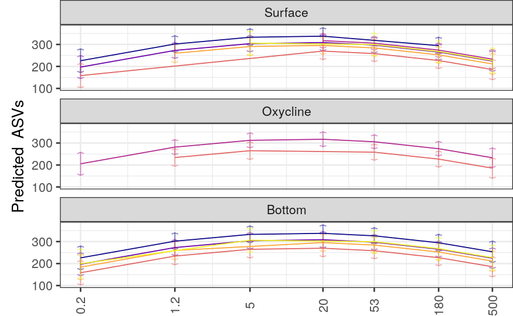

```r
plotObs_pred <-  diversityData %>%
#filter(Depth %in% c("Surface", "Bottom")) %>%
  ggplot(aes(x = Size_Class, y = pred_obs, shape = as.factor(Station), fill = as.factor(Station))) +
  geom_segment(aes(y = pred_obs - 2 * se_obs, yend = pred_obs + 2 * se_obs, xend = Size_Class, color = as.factor(Station)), arrow = arrow(angle = 70, length = unit(0.05, "in"), ends = "both"), alpha = 0.5)  +
  plotSpecs2 + ylab("Predicted  ASVs")
plotObs_pred
```

## Richness

```r
predict(chao1Mod, se.fit = TRUE)
```

```
$fit
       1        2        3        4        5        6        7        8        9       10       11       12       13       14
457.0580 457.0580 350.8054 350.8054 439.5649 284.1643 284.1643 402.9625 346.3763 657.2446 657.2446 550.9919 550.9919 639.7515
      15       16       17       18       19       20       21       22       23       24       25       26       27       28
484.3508 484.3508 603.1491 603.1491 735.0373 735.0373 628.7847 628.7847 717.5442 562.1436 562.1436 680.9419 624.3556 624.3556
      29       30       31       32       33       34       35       36       37       38       39       40       41       42
741.2781 741.2781 635.0254 635.0254 723.7850 723.7850 568.3843 568.3843 687.1826 687.1826 704.7685 598.5159 598.5159 687.2754
      43       44       45       46       47       48       49       50       51       52       53       54       55       56
687.2754 531.8748 531.8748 531.8748 650.6731 650.6731 594.0868 594.0868 611.2120 611.2120 504.9594 504.9594 593.7189 593.7189
      57       58       59       60       61       62       63       64       65       66       67       68       69       70
438.3183 438.3183 438.3183 557.1165 557.1165 500.5303 500.5303 492.2801 386.0274 386.0274 474.7870 474.7870 319.3863 319.3863
      71       72       73       74       75
319.3863 438.1846 438.1846 381.5984 381.5984

$se.fit
 [1]  85.55513  85.55513  83.22254  83.22254  82.77841  88.06656  88.06656  93.01152 107.90099  60.01577  60.01577  58.06185
[13]  58.06185  54.52685  63.52796  63.52796  68.16528  68.16528  61.03570  61.03570  59.57170  59.57170  54.63888  63.67601
[25]  63.67601  67.22081  89.32181  89.32181  61.02880  61.02880  59.46679  59.46679  53.76942  53.76942  62.16717  62.16717
[37]  65.22457  65.22457  58.84208  56.81629  56.81629  50.71479  50.71479  58.46525  58.46525  58.46525  61.60678  61.60678
[49]  84.17883  84.17883  61.22024  61.22024  58.40850  58.40850  52.87763  52.87763  58.41328  58.41328  58.41328  61.81220
[61]  61.81220  82.78526  82.78526  77.53835  74.51695  74.51695  70.83472  70.83472  73.35767  73.35767  73.35767  76.52591
[73]  76.52591  92.65014  92.65014

$df
[1] 69

$residual.scale
[1] 244.5561
```

```r
diversityData$pred_chao1 = predict(chao1Mod, se.fit = TRUE)$fit
diversityData$se_chao1 = predict(chao1Mod, se.fit = TRUE)$se.fit
```

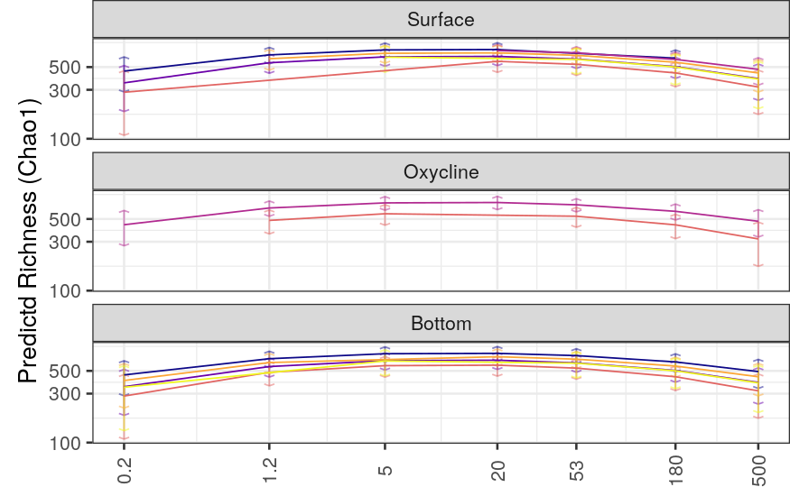

```r
plotChao1_pred <-  diversityData %>%

#filter(Depth %in% c("Surface", "Bottom")) %>%
  ggplot(aes(x = Size_Class, y = pred_chao1, shape = as.factor(Station), fill = as.factor(Station))) +
  geom_segment(aes(y = pred_chao1 - 2 * se_chao1, yend = pred_chao1 + 2 * se_chao1, xend = Size_Class, color = as.factor(Station)), arrow = arrow(angle = 70, length = unit(0.05, "in"), ends = "both"), alpha = 0.5)  +
  plotSpecs2 + ylab("Predictd Richness (Chao1)") + scale_y_log10()
plotChao1_pred
```

## Shannon Diversity

```r
predict(shanMod, se.fit = TRUE)
```

```
$fit
       1        2        3        4        5        6        7        8        9       10       11       12       13       14
4.515418 4.515418 4.363121 4.363121 4.293452 4.011014 4.011014 4.095825 4.401161 4.963917 4.963917 4.811620 4.811620 4.741951
      15       16       17       18       19       20       21       22       23       24       25       26       27       28
4.459513 4.459513 4.544324 4.544324 5.153713 5.153713 5.001416 5.001416 4.931747 4.649310 4.649310 4.734120 5.039457 5.039457
      29       30       31       32       33       34       35       36       37       38       39       40       41       42
5.195928 5.195928 5.043631 5.043631 4.973962 4.973962 4.691524 4.691524 4.776335 4.776335 5.141747 4.989450 4.989450 4.919781
      43       44       45       46       47       48       49       50       51       52       53       54       55       56
4.919781 4.637343 4.637343 4.637343 4.722154 4.722154 5.027491 5.027491 4.975858 4.975858 4.823561 4.823561 4.753892 4.753892
      57       58       59       60       61       62       63       64       65       66       67       68       69       70
4.471454 4.471454 4.471454 4.556265 4.556265 4.861602 4.861602 4.753672 4.601375 4.601375 4.531706 4.531706 4.249268 4.249268
      71       72       73       74       75
4.249268 4.334079 4.334079 4.639416 4.639416

$se.fit
 [1] 0.16159297 0.16159297 0.15718727 0.15718727 0.15634842 0.16633646 0.16633646 0.17567630 0.20379890 0.11335528 0.11335528
[12] 0.10966482 0.10966482 0.10298805 0.11998897 0.11998897 0.12874774 0.12874774 0.11528169 0.11528169 0.11251655 0.11251655
[23] 0.10319965 0.12026859 0.12026859 0.12696387 0.16870733 0.16870733 0.11526866 0.11526866 0.11231841 0.11231841 0.10155745
[34] 0.10155745 0.11741876 0.11741876 0.12319345 0.12319345 0.11113847 0.10731225 0.10731225 0.09578799 0.09578799 0.11042673
[45] 0.11042673 0.11042673 0.11636033 0.11636033 0.15899347 0.15899347 0.11563025 0.11563025 0.11031954 0.11031954 0.09987306
[56] 0.09987306 0.11032857 0.11032857 0.11032857 0.11674832 0.11674832 0.15636135 0.15636135 0.14645121 0.14074453 0.14074453
[67] 0.13378967 0.13378967 0.13855491 0.13855491 0.13855491 0.14453896 0.14453896 0.17499373 0.17499373

$df
[1] 69

$residual.scale
[1] 0.4619074
```

```r
diversityData$pred_shanH = predict(shanMod, se.fit = TRUE)$fit
diversityData$se_shanH = predict(shanMod, se.fit = TRUE)$se.fit
```

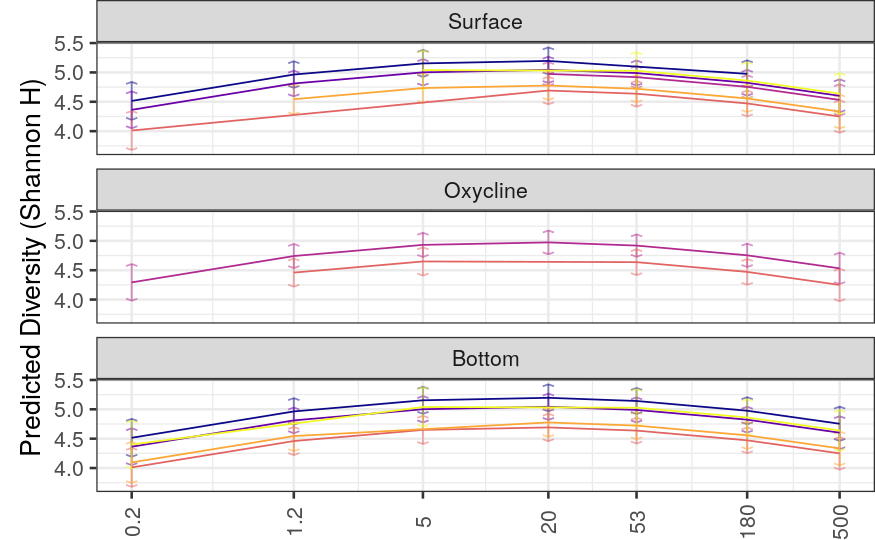

```r
plotShannonH_pred <- diversityData %>%

 #filter(Depth %in% c("Surface", "Bottom")) %>%
  ggplot(aes(x = Size_Class, y = pred_shanH, shape = as.factor(Station), fill = as.factor(Station))) +
  geom_segment(aes(y = pred_shanH - 2 * se_shanH, yend = pred_shanH + 2 * se_shanH, xend = Size_Class, color = as.factor(Station)), arrow = arrow(angle = 70, length = unit(0.05, "in"), ends = "both"),  alpha = 0.5)  +
  plotSpecs2 + ylab("Predicted Diversity (Shannon H)") #+ scale_y_log10()
plotShannonH_pred
```

## Evenness

```r
predict(pielouMod, se.fit = TRUE)
```

```
$fit
          1           2           3           4           5           6           7           8           9          10
0.019931709 0.019931709 0.022519585 0.022519585 0.021450798 0.025124975 0.025124975 0.022290200 0.019609243 0.010743770
         11          12          13          14          15          16          17          18          19          20
0.010743770 0.013331646 0.013331646 0.012262860 0.015937036 0.015937036 0.013102261 0.013102261 0.006710279 0.006710279
         21          22          23          24          25          26          27          28          29          30
0.009298155 0.009298155 0.008229368 0.011903545 0.011903545 0.009068770 0.006387813 0.006387813 0.005580899 0.005580899
         31          32          33          34          35          36          37          38          39          40
0.008168776 0.008168776 0.007099989 0.007099989 0.010774166 0.010774166 0.007939391 0.007939391 0.006432065 0.009019942
         41          42          43          44          45          46          47          48          49          50
0.009019942 0.007951155 0.007951155 0.011625332 0.011625332 0.011625332 0.008790557 0.008790557 0.006109599 0.006109599
         51          52          53          54          55          56          57          58          59          60
0.009420805 0.009420805 0.012008681 0.012008681 0.010939894 0.010939894 0.014614071 0.014614071 0.014614071 0.011779296
         61          62          63          64          65          66          67          68          69          70
0.011779296 0.009098339 0.009098339 0.013557654 0.016145531 0.016145531 0.015076744 0.015076744 0.018750921 0.018750921
         71          72          73          74          75
0.018750921 0.015916146 0.015916146 0.013235189 0.013235189

$se.fit
 [1] 0.005352725 0.005352725 0.005206787 0.005206787 0.005179000 0.005509852 0.005509852 0.005819231 0.006750785 0.003754864
[11] 0.003754864 0.003632618 0.003632618 0.003411452 0.003974603 0.003974603 0.004264735 0.004264735 0.003818676 0.003818676
[21] 0.003727081 0.003727081 0.003418461 0.003983866 0.003983866 0.004205645 0.005588386 0.005588386 0.003818244 0.003818244
[31] 0.003720518 0.003720518 0.003364064 0.003364064 0.003889466 0.003889466 0.004080751 0.004080751 0.003681433 0.003554690
[41] 0.003554690 0.003172952 0.003172952 0.003657857 0.003657857 0.003657857 0.003854405 0.003854405 0.005266617 0.005266617
[51] 0.003830222 0.003830222 0.003654306 0.003654306 0.003308269 0.003308269 0.003654605 0.003654605 0.003654605 0.003867257
[61] 0.003867257 0.005179429 0.005179429 0.004851158 0.004662126 0.004662126 0.004431748 0.004431748 0.004589595 0.004589595
[71] 0.004589595 0.004787815 0.004787815 0.005796621 0.005796621

$df
[1] 69

$residual.scale
[1] 0.01530056
```

```r
diversityData$pred_pielouJ = predict(pielouMod, se.fit = TRUE)$fit
diversityData$se_pielouJ = predict(pielouMod, se.fit = TRUE)$se.fit
```

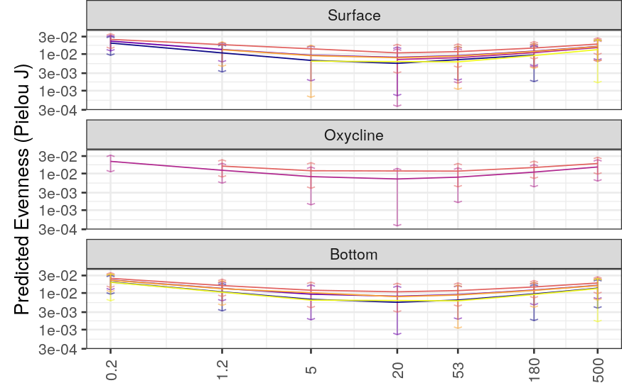

```r
plot_pielouJ_pred <- diversityData %>%

#filter(Depth %in% c("Surface", "Bottom")) %>%
  ggplot(aes(x = Size_Class, y = pred_pielouJ, shape = as.factor(Station), fill = as.factor(Station))) +
  geom_segment(aes(y = pred_pielouJ - 2 * se_pielouJ, yend = pred_pielouJ + 2 * se_pielouJ, xend = Size_Class, color = as.factor(Station), alpha = 0.5), arrow = arrow(angle = 70, length = unit(0.05, "in"), ends = "both"))  +
  plotSpecs2 + ylab("Predicted Evenness (Pielou J)") + scale_y_log10()
plot_pielouJ_pred
```

## Combined prediction plot

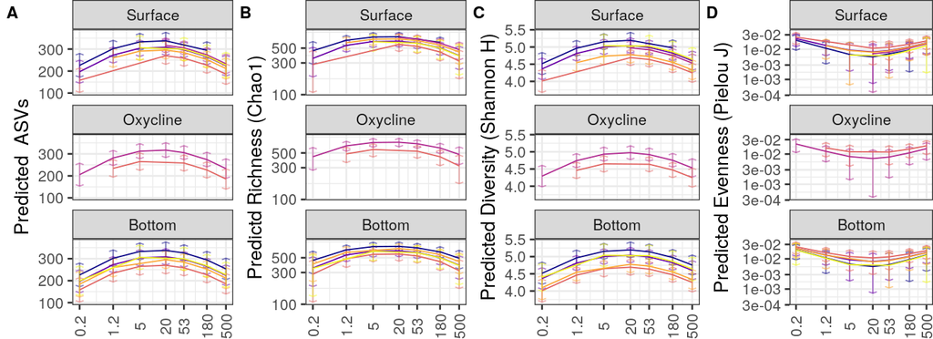

```r
plotPredictions <- plot_grid(plotObs_pred, plotChao1_pred, plotShannonH_pred, plot_pielouJ_pred, nrow = 1, labels = LETTERS)
plotPredictions
```

```r
ggsave(here::here("Figures", "ConventionalAlphaPredictions.png"), plotPredictions, width = 11, height = 4)
```

## Even combindeder

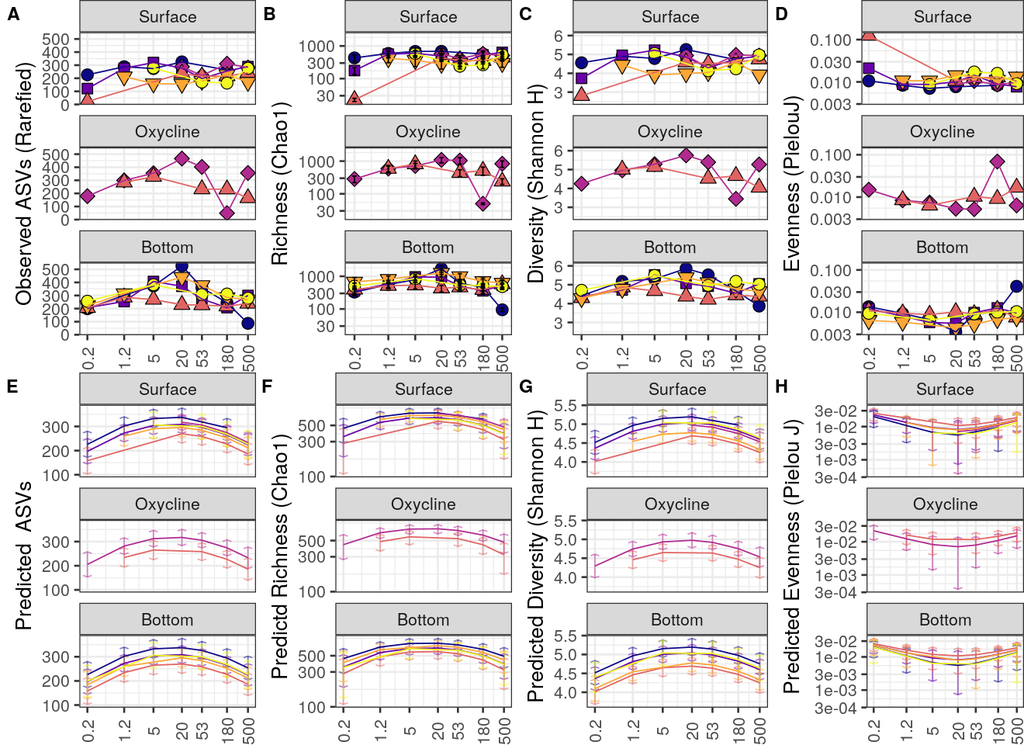

```r
plot_grid(plotObs, plotChao1, plotShan, plotPielou,
          plotObs_pred, plotChao1_pred, plotShannonH_pred, plot_pielouJ_pred,
          nrow = 2, labels = LETTERS)
```

# Combined summary table

```r
alphaSummary <- tibble(
  metric = c("Observed ASVs", "Richness (Chao1)", "Diversity (Shannon H)", "Evenness (Pielou J)"),
  model = list(obsMod, chao1Mod, shanMod, pielouMod)
)

alphaSummary <- alphaSummary %>%
  mutate(df = map(model, ~broom::tidy(summary(.))))

alphaSummary <- alphaSummary %>%
  select(-model) %>%
  unnest(df)

alphaSummary <- alphaSummary %>%
  rename(Metric = metric, Term = term, Estimate = estimate, `Standard Error` = std.error, `T Value` = statistic, p = p.value) %>%
  mutate(Term = str_replace(Term, "^I?\\((.*)\\)", "\\1"),
         Term = str_replace(Term, "\\^2", "\\^2\\^"),
         Term = str_replace(Term, "depth", "Depth"),
         Term = str_replace(Term, "lat", "Latitude"),
         Term = str_replace(Term, "_", " ")# BOOKMARK!!
         ) %>%
  mutate(Estimate = format(Estimate, digits = 2, scientific = TRUE) %>%
           reformat_sci()
         ) %>%
  mutate(`Standard Error` = format(`Standard Error`, digits = 2, scientific = TRUE) %>%
           reformat_sci()
  ) %>%
  mutate(`T Value` = format(`T Value`, digits = 2, scientific = FALSE)) %>%
  mutate(p = if_else(p < 0.001, "< 0.001", format(round(p, digits = 3)))) %>%
  rename(`Standard\nError` = `Standard Error`) %>%
  identity()

alphaSummary %>% flextable() %>% merge_v(j = 1) %>% theme_vanilla() %>%
  bold(i = ~ p< 0.05, j = "p") %>%
  colformat_md() %>%
  set_table_properties(layout = "autofit") %>%
  align(j = -c(1:2), align = "right")
```

| Metric | Term | Estimate | Standard Error | T Value | p |
| --- | --- | --- | --- | --- | --- |
| Observed ASVs | Intercept | 2.6 x 105 | 1.4 x 105 | 1.90 | 0.061 |
|  | log(Size Class) | 3.3 x 101 | 8.2 x 100 | 4.04 | < 0.001 |
|  | log(Size Class)2 | -6.4 x 100 | 1.5 x 100 | -4.22 | < 0.001 |
|  | Latitude | -1.3 x 104 | 7.0 x 103 | -1.90 | 0.061 |
|  | Latitude2 | 1.7 x 102 | 9.2 x 101 | 1.90 | 0.061 |
|  | Depth | 4.1 x 100 | 3.2 x 100 | 1.27 | 0.209 |
| Richness (Chao1) | Intercept | 8.6 x 105 | 4.3 x 105 | 2.01 | 0.048 |
|  | log(Size Class) | 8.6 x 101 | 2.6 x 101 | 3.32 | 0.001 |
|  | log(Size Class)2 | -1.8 x 101 | 4.8 x 100 | -3.67 | < 0.001 |
|  | Latitude | -4.5 x 104 | 2.2 x 104 | -2.02 | 0.048 |
|  | Latitude2 | 5.9 x 102 | 2.9 x 102 | 2.02 | 0.048 |
|  | Depth | 1.9 x 101 | 1.0 x 101 | 1.88 | 0.065 |
| Diversity (Shannon H) | Intercept | 1.5 x 103 | 8.1 x 102 | 1.85 | 0.068 |
|  | log(Size Class) | 2.0 x 10-1 | 4.9 x 10-2 | 4.04 | < 0.001 |
|  | log(Size Class)2 | -3.6 x 10-2 | 9.1 x 10-3 | -3.99 | < 0.001 |
|  | Latitude | -7.8 x 101 | 4.2 x 101 | -1.85 | 0.069 |
|  | Latitude2 | 1.0 x 100 | 5.5 x 10-1 | 1.85 | 0.069 |
|  | Depth | 1.3 x 10-2 | 1.9 x 10-2 | 0.68 | 0.501 |
| Evenness (Pielou J) | Intercept | -2.4 x 101 | 2.7 x 101 | -0.91 | 0.367 |
|  | log(Size Class) | -4.1 x 10-3 | 1.6 x 10-3 | -2.52 | 0.014 |
|  | log(Size Class)2 | 7.2 x 10-4 | 3.0 x 10-4 | 2.36 | 0.021 |
|  | Latitude | 1.3 x 100 | 1.4 x 100 | 0.91 | 0.367 |
|  | Latitude2 | -1.7 x 10-2 | 1.8 x 10-2 | -0.91 | 0.368 |
|  | Depth | -3.9 x 10-4 | 6.4 x 10-4 | -0.60 | 0.551 |

# Now considering breakaway values

```r
richSummary %>% rename_(.dots = setNames(names(.), paste0('break_', names(.))))
```

| break_estimate | break_error | break_lower | break_upper | break_sample_names | break_name | break_model |
| --- | --- | --- | --- | --- | --- | --- |
| 1149.49504 | 74.215916 | 840.37860 | 9.856215e+03 | 3-1-B-0-2 | breakaway | Negative Binomial |
| 3759.74532 | 600.496435 | 2190.46255 | 1.549200e+05 | 3-1-B-1-2 | breakaway | Kemp |
| 852.96618 | 95.814707 | 626.33788 | 1.070146e+04 | 3-1-B-180 | breakaway | Kemp |
| 8590.39015 | 367.922431 | 4335.69492 | 1.720644e+05 | 3-1-B-20 | breakaway | Kemp |
| 2272.34292 | 128.244212 | 1422.82197 | 2.732167e+04 | 3-1-B-5 | breakaway | Kemp |
| 100.14731 | 9.881637 | 87.75180 | 3.169175e+02 | 3-1-B-500 | breakaway | Negative Binomial |
| 2104.54130 | 197.020727 | 1259.66143 | 4.120062e+04 | 3-1-B-53 | breakaway | Kemp |
| 2274.51944 | 342.357498 | 1130.16308 | 7.971937e+04 | 3-1-S-0-2 | breakaway | Kemp |
| 3711.49178 | 372.223587 | 1937.21385 | 1.096785e+05 | 3-1-S-1-2 | breakaway | Kemp |
| 3936.99093 | 995.618813 | 2130.27993 | 2.515435e+05 | 3-1-S-180 | breakaway | Kemp |

[output cut: 65 more lines]

```r
diversityDataWB <- full_join(diversityData,
                             richSummary %>% rename_(.dots = setNames(names(.), paste0('break_', names(.)))),
                             by = c("ID" = "break_sample_names"), suffix = c("", "_break")) %>%
  mutate(pielouJ2 = shannonH/break_estimate) %>%
  identity()
```

```r
diversityDataWB
```

| ID | copiesPerL | Station | Size_Class | Depth | Bin_Size | DNAperLiter | MassperLiter | ParticlesPerLiter | Flag | δ13CVPDB (‰) | δ15NAir (‰) | CarbonPerLiter_mg | NitrogenPerLiter_mg | Depth_m | Temperature | Salinity | Oxygen | Fluorescence | PAR | pH | lat | long | UTMX | UTMY | depth | do | Depth2 | S.obs | S.chao1 | … |
| --- | --- | --- | --- | --- | --- | --- | --- | --- | --- | --- | --- | --- | --- | --- | --- | --- | --- | --- | --- | --- | --- | --- | --- | --- | --- | --- | --- | --- | --- | --- |
| 3-1-S-0-2 | 7.688621e+08 | 3.1 | 0.2 | Surface | 1.0 | 3.690476e+03 | NA | NA | FALSE | NA | NA | NA | NA | 3.0 | 28.88710 | 1.309420 | 3.90454898 | 1.9880367 | 8.56664490 | 7.918184 | 39.24950 | -76.24050 | 392959 | 4345197 | 13.3 | 85 | Surface | 226 | 431.02778 | … |
| 3-1-B-0-2 | 4.968996e+08 | 3.1 | 0.2 | Bottom | 1.0 | 3.037500e+03 | NA | NA | FALSE | NA | NA | NA | NA | 7.0 | 28.67496 | 2.595564 | 4.30725778 | 1.9354067 | 0.02845996 | 7.657844 | 39.24950 | -76.24050 | 392959 | 4345197 | 13.3 | 85 | NotSurface | 199 | 327.77500 | … |
| 3-2-S-0-2 | 1.642566e+09 | 3.2 | 0.2 | Surface | 1.0 | 3.625000e+03 | NA | NA | FALSE | NA | NA | NA | NA | 3.0 | 28.21413 | 5.391554 | 4.23788913 | 2.4661370 | 3.93922717 | 7.917870 | 39.16369 | -76.30631 | 387143 | 4335754 | 12.2 | 54 | Surface | 121 | 177.00000 | … |
| 3-2-B-0-2 | 1.221752e+09 | 3.2 | 0.2 | Bottom | 1.0 | 4.647059e+03 | NA | NA | FALSE | NA | NA | NA | NA | 7.0 | 27.51617 | 7.895728 | 1.34046739 | 1.6939457 | 0.01273587 | 7.672500 | 39.16369 | -76.30631 | 387143 | 4335754 | 12.2 | 54 | NotSurface | 207 | 360.27027 | … |
| 3-3-B-0-2 | 9.999237e+08 | 3.3 | 0.2 | Oxycline | 1.0 | 1.839286e+03 | NA | NA | FALSE | NA | NA | NA | NA | 7.0 | 28.91929 | 6.767270 | 4.83748261 | 3.0308065 | 0.01259917 | 8.394435 | 38.99596 | -76.35967 | 382254 | 4317207 | 24.1 | 10 | NotSurface | 179 | 284.33333 | … |
| 4-3-S-0-2 | 1.625097e+07 | 4.3 | 0.2 | Surface | 1.0 | 6.875000e+03 | NA | NA | FALSE | NA | NA | NA | NA | 3.0 | 29.55167 | 9.220331 | 6.43551556 | 2.5768711 | 5.49693556 | 8.723911 | 38.55505 | -76.42794 | 375578 | 4268368 | 27.1 | 8 | Surface | 22 | 22.50000 | … |
| 4-3-B-0-2 | 6.977776e+08 | 4.3 | 0.2 | Bottom | 1.0 | 1.589286e+03 | NA | NA | FALSE | NA | NA | NA | NA | 19.0 | 23.40519 | 19.681290 | 0.03736044 | 0.5182604 | 0.01260256 | 7.612549 | 38.55505 | -76.42794 | 375578 | 4268368 | 27.1 | 8 | NotSurface | 206 | 396.78125 | … |
| C_5P1B_0P2 | 1.124669e+09 | 5.1 | 0.2 | Bottom | 1.0 | 2.962500e+03 | NA | NA | FALSE | NA | NA | NA | NA | 32.5 | 23.44238 | 20.454067 | 0.03151667 | 0.5269667 | 0.01257083 | 7.581167 | 38.31870 | -76.29215 | 387043 | 4241966 | 34.3 | 11 | NotSurface | 223 | 671.63636 | … |
| 5-5-B-0-2 | 2.292876e+10 | 5.5 | 0.2 | Bottom | 1.0 | 4.354839e+03 | NA | NA | FALSE | NA | NA | NA | NA | 13.0 | 25.58956 | 20.045743 | 0.27383409 | 0.6455318 | 0.02345916 | 7.780182 | 37.69180 | -76.18967 | 395112 | 4172286 | 17.7 | 56 | NotSurface | 256 | 498.79070 | … |
| 3-1-S-1-2 | 1.467958e+09 | 3.1 | 1.2 | Surface | 3.8 | 3.478723e+03 | 6.34000000 | 2.665037e+09 | FALSE | -28.36021 | 10.029592 | 1.15736939 | 0.1558903972 | 3.0 | 28.88710 | 1.309420 | 3.90454898 | 1.9880367 | 8.56664490 | 7.918184 | 39.24950 | -76.24050 | 392959 | 4345197 | 13.3 | 85 | Surface | 288 | 589.96078 | … |

[output cut: 65 more lines]

```r
pielouMod2 <- lm(pielouJ2 ~ log(Size_Class) + I(log(Size_Class)^2) + lat + I(lat^2) + depth, data = diversityDataWB)
summary(pielouMod2)
```

```
Call:
lm(formula = pielouJ2 ~ log(Size_Class) + I(log(Size_Class)^2) +
    lat + I(lat^2) + depth, data = diversityDataWB)

Residuals:
      Min        1Q    Median        3Q       Max
-0.013957 -0.005061 -0.002495  0.000922  0.105949

Coefficients:
                       Estimate Std. Error t value Pr(>|t|)
(Intercept)          -1.979e+01  2.753e+01  -0.719   0.4747
log(Size_Class)      -3.293e-03  1.668e-03  -1.975   0.0523 .
I(log(Size_Class)^2)  5.753e-04  3.103e-04   1.854   0.0680 .
lat                   1.029e+00  1.435e+00   0.717   0.4756
I(lat^2)             -1.337e-02  1.868e-02  -0.716   0.4765
depth                -2.434e-04  6.606e-04  -0.368   0.7137
---
Signif. codes:  0 ‘***’ 0.001 ‘**’ 0.01 ‘*’ 0.05 ‘.’ 0.1 ‘ ’ 1

Residual standard error: 0.01568 on 69 degrees of freedom
Multiple R-squared:  0.06741,   Adjusted R-squared:  -0.0001743
F-statistic: 0.9974 on 5 and 69 DF,  p-value: 0.4259
```

Ok. So the narrative makes sense. Alpha diveristy is driven by variability in richness rather than evenness. Why would we see an effect in chao1 but not breakaway? Because chao1 is more driven by abundant stuff that makes the rarification threshold. My first hunch is that chao1 responds to evenness, but actually that shouldn’t have any effect since there is no evenness variability? Or maybe just that breakaway is more variable (because it detects fine level differences in rare species) and that doesn’t map as nicely with overall patterns.

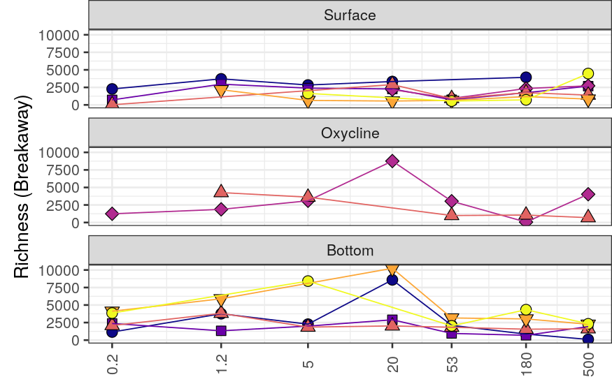

```r
plotBreak <- diversityDataWB %>%

#filter(Depth %in% c("Surface", "Bottom")) %>%
  ggplot(aes(x = Size_Class, y = break_estimate, shape = as.factor(Station), fill = as.factor(Station))) +
  plotSpecs +
  #scale_y_log10()+
  ylab("Richness (Breakaway)")
plotBreak
```

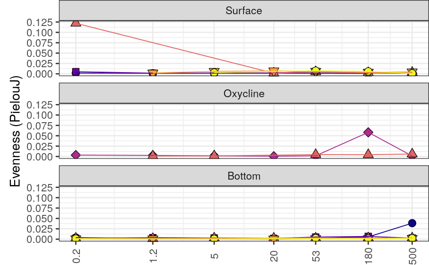

```r
plotPielou2 <- diversityDataWB %>%

#filter(Depth %in% c("Surface", "Bottom")) %>%
  ggplot(aes(x = Size_Class, y = pielouJ2, shape = as.factor(Station), fill = as.factor(Station))) +
  plotSpecs +
  #scale_y_log10()+
  ylab("Evenness (PielouJ)")
plotPielou2
```

## Redo predictions for good measure

```r
predict(pielouMod2, se.fit = TRUE)
```

```
$fit
            1             2             3             4             5             6             7             8             9
 0.0116894331  0.0116894331  0.0136061585  0.0136061585  0.0133646942  0.0160257236  0.0160257236  0.0139513949  0.0099030725
           10            11            12            13            14            15            16            17            18
 0.0043173402  0.0043173402  0.0062340656  0.0062340656  0.0059926013  0.0086536307  0.0086536307  0.0065793019  0.0065793019
           19            20            21            22            23            24            25            26            27
 0.0010882296  0.0010882296  0.0030049550  0.0030049550  0.0027634907  0.0054245201  0.0054245201  0.0033501914 -0.0006981310
           28            29            30            31            32            33            34            35            36
-0.0006981310  0.0001952100  0.0001952100  0.0021119354  0.0021119354  0.0018704711  0.0018704711  0.0045315005  0.0045315005
           37            38            39            40            41            42            43            44            45
 0.0024571717  0.0024571717  0.0008910254  0.0028077509  0.0028077509  0.0025662865  0.0025662865  0.0052273159  0.0052273159
           46            47            48            49            50            51            52            53            54
 0.0052273159  0.0031529872  0.0031529872 -0.0008953352 -0.0008953352  0.0033094605  0.0033094605  0.0052261859  0.0052261859
           55            56            57            58            59            60            61            62            63
 0.0049847216  0.0049847216  0.0076457510  0.0076457510  0.0076457510  0.0055714222  0.0055714222  0.0015230999  0.0015230999
           64            65            66            67            68            69            70            71            72
 0.0066493588  0.0085660842  0.0085660842  0.0083246199  0.0083246199  0.0109856493  0.0109856493  0.0109856493  0.0089113206
           73            74            75
 0.0089113206  0.0048629982  0.0048629982

$se.fit
 [1] 0.005485740 0.005485740 0.005336176 0.005336176 0.005307699 0.005646772 0.005646772 0.005963840 0.006918543 0.003848173
[11] 0.003848173 0.003722889 0.003722889 0.003496227 0.004073372 0.004073372 0.004370714 0.004370714 0.003913570 0.003913570
[21] 0.003819699 0.003819699 0.003503410 0.004082865 0.004082865 0.004310155 0.005727258 0.005727258 0.003913128 0.003913128
[31] 0.003812973 0.003812973 0.003447661 0.003447661 0.003986119 0.003986119 0.004182158 0.004182158 0.003772917 0.003643024
[41] 0.003643024 0.003251800 0.003251800 0.003748755 0.003748755 0.003748755 0.003950188 0.003950188 0.005397493 0.005397493
[51] 0.003925403 0.003925403 0.003745116 0.003745116 0.003390480 0.003390480 0.003745422 0.003745422 0.003745422 0.003963359
[61] 0.003963359 0.005308138 0.005308138 0.004971709 0.004777980 0.004777980 0.004541877 0.004541877 0.004703647 0.004703647
[71] 0.004703647 0.004906793 0.004906793 0.005940668 0.005940668

$df
[1] 69

$residual.scale
[1] 0.01568078
```

```r
diversityDataWB$pred_pielouJ2 = predict(pielouMod2, se.fit = TRUE)$fit
diversityDataWB$se_pielouJ2 = predict(pielouMod2, se.fit = TRUE)$se.fit
```

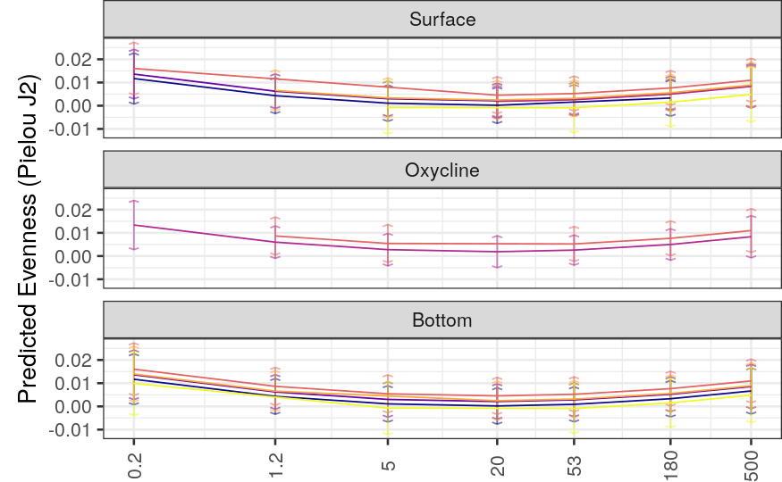

```r
plot_pielouJ2_pred <- diversityDataWB %>%

#filter(Depth %in% c("Surface", "Bottom")) %>%
  ggplot(aes(x = Size_Class, y = pred_pielouJ2, shape = as.factor(Station), fill = as.factor(Station))) +
  geom_segment(aes(y = pred_pielouJ2 - 2 * se_pielouJ2, yend = pred_pielouJ2 + 2 * se_pielouJ2, xend = Size_Class, color = as.factor(Station), alpha = 0.5), arrow = arrow(angle = 70, length = unit(0.05, "in"), ends = "both"))  +
  plotSpecs2 + ylab("Predicted Evenness (Pielou J2)") #+ scale_y_log10()
plot_pielouJ2_pred
```

## Breakaway richness subplots

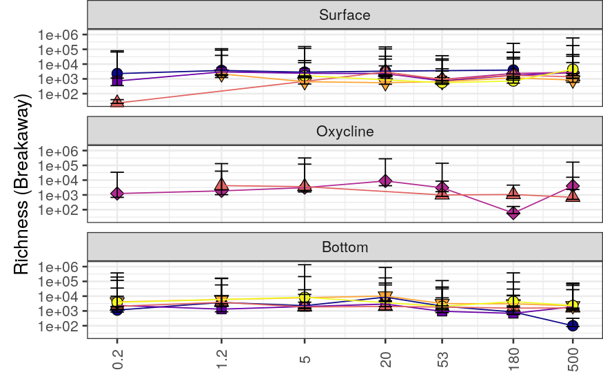

```r
plotBreakaway <- diversityDataWB %>%
#filter(Depth %in% c("Surface", "Bottom")) %>%
  ggplot(aes(x = Size_Class, y = break_estimate, shape = as.factor(Station), fill = as.factor(Station))) +
  plotSpecs +
  geom_errorbar(aes(ymin = break_lower, ymax = break_upper), width = -.1) +
  scale_y_log10() +
  ylab("Richness (Breakaway)")
plotBreakaway
```

```r
#predict(breakLm, se.fit = TRUE)
# doesn't work because built with a different data frame
```

Why are these not smooth curves?!! What if I redo the model, this time with the same data frame

```r
breakLm2 <- lm(break_estimate ~ log(Size_Class) + I(log(Size_Class) ^2) + lat +  I(lat^2) + depth ,data = diversityDataWB)
breakLm2 %>% summary()
```

```
Call:
lm(formula = break_estimate ~ log(Size_Class) + I(log(Size_Class)^2) +
    lat + I(lat^2) + depth, data = diversityDataWB)

Residuals:
    Min      1Q  Median      3Q     Max
-2974.5 -1191.2  -151.6   599.9  6768.1

Coefficients:
                       Estimate Std. Error t value Pr(>|t|)
(Intercept)          7124615.61 3339862.88   2.133   0.0365 *
log(Size_Class)          244.45     202.35   1.208   0.2312
I(log(Size_Class)^2)     -75.16      37.65  -1.996   0.0498 *
lat                  -370568.38  174035.93  -2.129   0.0368 *
I(lat^2)                4817.28    2265.61   2.126   0.0371 *
depth                    151.10      80.15   1.885   0.0636 .
---
Signif. codes:  0 ‘***’ 0.001 ‘**’ 0.01 ‘*’ 0.05 ‘.’ 0.1 ‘ ’ 1

Residual standard error: 1902 on 69 degrees of freedom
Multiple R-squared:  0.1414,    Adjusted R-squared:  0.0792
F-statistic: 2.273 on 5 and 69 DF,  p-value: 0.0567
```

Note the non statistical significance overall

```r
#predict(breakLm2, se.fit = TRUE)
diversityDataWB$pred_break = predict(breakLm2, se.fit = TRUE)$fit
diversityDataWB$se_break = predict(breakLm2, se.fit = TRUE)$se.fit
```

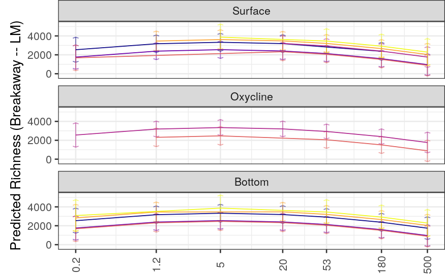

```r
plot_break_pred <- diversityDataWB %>%

#filter(Depth %in% c("Surface", "Bottom")) %>%
#  filter(Station == 4.3) %>%
  ggplot(aes(x = Size_Class, y = pred_break, shape = as.factor(Station), fill = as.factor(Station))) +
  geom_segment(aes(y = pred_break - 2 * se_break, yend = pred_break + 2 * se_break, xend = Size_Class, color = as.factor(Station), alpha = 0.5), arrow = arrow(angle = 70, length = unit(0.05, "in"), ends = "both"))  +
  plotSpecs2 + ylab("Predicted Richness (Breakaway -- LM)") #+ scale_y_log10()
plot_break_pred
```

## Rebuilding combined products

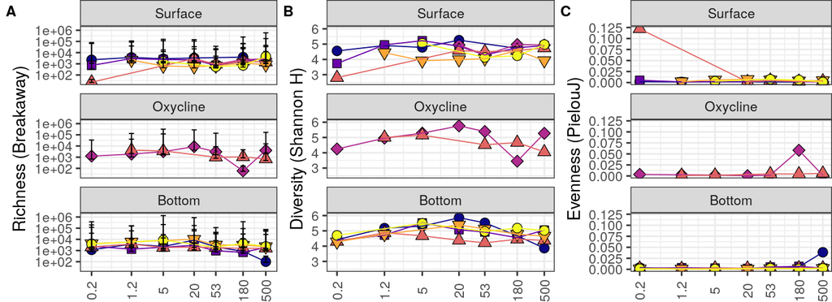

```r
plotAlphaWB <- plot_grid(plotBreakaway, plotShan, plotPielou2, nrow = 1, labels = LETTERS)
plotAlphaWB
```

```r
ggsave(here::here("Figures", "BreakawayAlpha.png"), plotAlphaWB, width = 8, height = 4)
```

Summary table I want both breakaway metrics here

```r
bettaTable <- myBet$table %>%
  as.data.frame() %>%
  rename(estimate = Estimates,
         `std.error` = `Standard Errors`,
         `p.value`=`p-values`
         ) %>%
  mutate(`statistic` = NA) %>%
  rownames_to_column(var = "term") %>%
  select(term, estimate, std.error, statistic, p.value) %>%
  as_tibble()
bettaTable
```

| term | estimate | std.error | statistic | p.value |
| --- | --- | --- | --- | --- |
| (Intercept) | 7124599.39073 | 238.1841898 | NA | 0.000 |
| log(Size_Class) | 115.12754 | 60.7376176 | NA | 0.058 |
| I(log(Size_Class)^2) | -50.49272 | 11.6218766 | NA | 0.000 |
| lat | -370742.10322 | 6.1494273 | NA | 0.000 |
| I(lat^2) | 4821.69098 | 0.1587166 | NA | 0.000 |
| depth | 150.02477 | 10.3193582 | NA | 0.000 |

```r
alphaSummary2 <- tibble(
  metric = c("Richness (Breakaway -- LM)", "Diversity (Shannon H)", "Evenness (Pielou J)"),
  model = list(breakLm, shanMod, pielouMod2)
)

alphaSummary2 <- alphaSummary2 %>%
  mutate(df = map(model, ~broom::tidy(summary(.))))

## Add in willis variables

breakawaySummary <- tibble(
  metric = "Richness (Breakaway -- Betta)",
  model = NULL,
  df = list(bettaTable)
)

alphaSummary2 = bind_rows(breakawaySummary, alphaSummary2)

alphaSummary2 <- alphaSummary2 %>%
  select(-model) %>%
  unnest(df)

alphaSummary2 <- alphaSummary2 %>%
  rename(Metric = metric, Term = term, Estimate = estimate, `Standard Error` = std.error, `T Value` = statistic, p = p.value) %>%
  mutate(Term = str_replace(Term, "^I?\\((.*)\\)", "\\1"),
         Term = str_replace(Term, "\\^2", "\\^2\\^"),
         Term = str_replace(Term, "depth", "Depth"),
         Term = str_replace(Term, "lat", "Latitude"),
         Term = str_replace(Term, "_", " ")# BOOKMARK!!
         ) %>%
  mutate(Estimate = format(Estimate, digits = 2, scientific = TRUE) %>%
           reformat_sci()
         ) %>%
  mutate(`Standard Error` = format(`Standard Error`, digits = 2, scientific = TRUE) %>%
           reformat_sci()
  ) %>%
  mutate(`T Value` = format(`T Value`, digits = 2, scientific = FALSE)) %>%
  mutate(p = if_else(p < 0.001, "< 0.001", format(round(p, digits = 3)))) %>%
  rename(`Standard\nError` = `Standard Error`) %>%
  identity()



alphaSummary2
```

| Metric | Term | Estimate | Standard Error | T Value | p |
| --- | --- | --- | --- | --- | --- |
| Richness (Breakaway -- Betta) | Intercept | 7.1 x 10^6^ | 2.4 x 10^2^ | NA | < 0.001 |
| Richness (Breakaway -- Betta) | log(Size Class) | 1.2 x 10^2^ | 6.1 x 10^1^ | NA | 0.058 |
| Richness (Breakaway -- Betta) | log(Size Class)^2^ | -5.0 x 10^1^ | 1.2 x 10^1^ | NA | < 0.001 |
| Richness (Breakaway -- Betta) | Latitude | -3.7 x 10^5^ | 6.1 x 10^0^ | NA | < 0.001 |
| Richness (Breakaway -- Betta) | Latitude^2^ | 4.8 x 10^3^ | 1.6 x 10^-1^ | NA | < 0.001 |
| Richness (Breakaway -- Betta) | Depth | 1.5 x 10^2^ | 1.0 x 10^1^ | NA | < 0.001 |
| Richness (Breakaway -- LM) | Intercept | 7.1 x 10^6^ | 3.3 x 10^6^ | 2.13 | 0.036 |
| Richness (Breakaway -- LM) | log(Size Class) | 2.4 x 10^2^ | 2.0 x 10^2^ | 1.21 | 0.231 |
| Richness (Breakaway -- LM) | log(Size Class)^2^ | -7.5 x 10^1^ | 3.8 x 10^1^ | -2.00 | 0.050 |
| Richness (Breakaway -- LM) | Latitude | -3.7 x 10^5^ | 1.7 x 10^5^ | -2.13 | 0.037 |

[output cut: 14 more lines]

```r
alphaTable2 <- alphaSummary2 %>% flextable() %>% merge_v(j = 1) %>% theme_vanilla() %>% bold(i = ~ p< 0.05, j = "p") %>% colformat_md() %>% set_table_properties(layout = "autofit") %>%
  align(j = -c(1:2), align = "right")
alphaTable2
```

| Metric | Term | Estimate | Standard Error | T Value | p |
| --- | --- | --- | --- | --- | --- |
| Richness (Breakaway – Betta) | Intercept | 7.1 x 106 | 2.4 x 102 | NA | < 0.001 |
|  | log(Size Class) | 1.2 x 102 | 6.1 x 101 | NA | 0.058 |
|  | log(Size Class)2 | -5.0 x 101 | 1.2 x 101 | NA | < 0.001 |
|  | Latitude | -3.7 x 105 | 6.1 x 100 | NA | < 0.001 |
|  | Latitude2 | 4.8 x 103 | 1.6 x 10-1 | NA | < 0.001 |
|  | Depth | 1.5 x 102 | 1.0 x 101 | NA | < 0.001 |
| Richness (Breakaway – LM) | Intercept | 7.1 x 106 | 3.3 x 106 | 2.13 | 0.036 |
|  | log(Size Class) | 2.4 x 102 | 2.0 x 102 | 1.21 | 0.231 |
|  | log(Size Class)2 | -7.5 x 101 | 3.8 x 101 | -2.00 | 0.050 |
|  | Latitude | -3.7 x 105 | 1.7 x 105 | -2.13 | 0.037 |
|  | Latitude2 | 4.8 x 103 | 2.3 x 103 | 2.13 | 0.037 |
|  | Depth | 1.5 x 102 | 8.0 x 101 | 1.89 | 0.064 |
| Diversity (Shannon H) | Intercept | 1.5 x 103 | 8.1 x 102 | 1.85 | 0.068 |
|  | log(Size Class) | 2.0 x 10-1 | 4.9 x 10-2 | 4.04 | < 0.001 |
|  | log(Size Class)2 | -3.6 x 10-2 | 9.1 x 10-3 | -3.99 | < 0.001 |
|  | Latitude | -7.8 x 101 | 4.2 x 101 | -1.85 | 0.069 |
|  | Latitude2 | 1.0 x 100 | 5.5 x 10-1 | 1.85 | 0.069 |
|  | Depth | 1.3 x 10-2 | 1.9 x 10-2 | 0.68 | 0.501 |
| Evenness (Pielou J) | Intercept | -2.0 x 101 | 2.8 x 101 | -0.72 | 0.475 |
|  | log(Size Class) | -3.3 x 10-3 | 1.7 x 10-3 | -1.97 | 0.052 |
|  | log(Size Class)2 | 5.8 x 10-4 | 3.1 x 10-4 | 1.85 | 0.068 |
|  | Latitude | 1.0 x 100 | 1.4 x 100 | 0.72 | 0.476 |
|  | Latitude2 | -1.3 x 10-2 | 1.9 x 10-2 | -0.72 | 0.477 |
|  | Depth | -2.4 x 10-4 | 6.6 x 10-4 | -0.37 | 0.714 |

```r
alphaTable2 %>% save_as_docx(path = here::here("Tables", "alphaTable2.docx"))
```

myBet$table

## And finally predictions from richness, diversity evenness again.

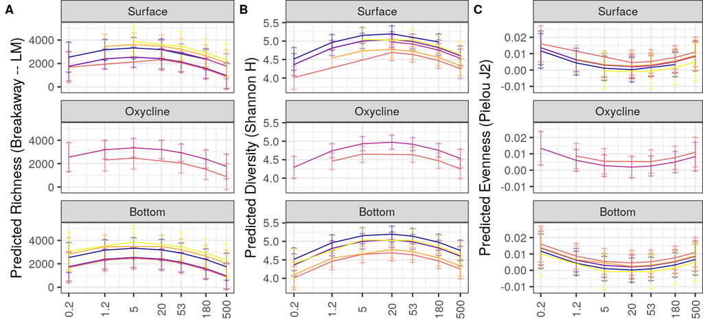

```r
plotAlphaWB_pred <- plot_grid(plot_break_pred,plotShannonH_pred,plot_pielouJ2_pred, nrow = 1, labels = LETTERS)
plotAlphaWB_pred
```

```r
ggsave(here::here("Figures", "BreakawayAlphaPredictions.png"), plot = plotAlphaWB_pred, width = 8, height = 5)
```